# The Final Assignment of IODS2017

Anni Norring

anni.norring@helsinki.fi

December 13th 2017

# Abstract:

In this final assignment I use logistic regression to find which variables can predict the probability of a given country achieving higher than average mean years of schooling. I use data from two UN indices, the Human Development Index and the Gender Inequality Index. I fit a logistic regression model to the data and calculate odds ratios. I also evaluate and validate the model using predictions and cross-validation.

# 1. Introduction

It is well documented that education provides a myriad of good: on average, more educated people earn more, live longer, are more healthy and lead in general more happy and fulfilling lives than the ones that are less educated. There are also dramatic differences in the amount of schooling citizens of different countries receive. For example, children in Finland can expect to stay in school for over 17 years, whereas their peers in Niger can expect to receive less than 6 years of schooling.

It is thus of interest to study what determines the levels of education across different countries. This is a multifaceted and complicated question well beyon the scope of a course work. I can however choose a small specific question to find an answer to.

# 2. Research question: Why do some countries manage to educate their citizens more than others?

In this my final assignment I will try to find out whether the differences in mean years of schooling across different countries can be explained by some of the other variables included in the United Nations Development Programme data on Human Development Index and Gender Inequality Index. That is, my research question is:

> What explains the differences in mean years of schooling across different countries?

I will create a dichotomous dependent variable by

1. calculating the average of mean years of schooling
2. and creating a new variable that takes value 0 if the mean years of schooling of a given country is less than average and value 1 if it is more than average.

Then I will run a logistic regression, where this new variable is the dependent variable. I will choose the independent variables according to analysis on the characteristics and correlations in the data, done in part 5.

My initial hypothesis are the following:

- countries with high gross national income (GNI) have higher than average years of schooling, i.e. positive correlation between variables GNI and Edu.high
- countries with higher share of population has secondary schooling have higher average years of schooling, i.e. positive correlation between variables Edu2.F, Edu2.M and Edu.high
- countries with higher life expectancy at birth have higher than average years of schooling, i.e. positive correlation between Life.Exp and Edu.high

However, it is important to remember that correlation and causality are not equivalent and in this case the causality most probably runs both ways. But let’s see what we can find out!

# 3. Data wrangling

The data I will utilise comes from the Human Development Index (HDI) and the Gender Inequality Index (GII), which are both compiled by the United Nations Development programme.

**For this final assignment, you can find my data wrangling R script from [here](https://github.com/anorring/IODS-final/blob/master/create_final_human.R) and my preprocessed data set from [here](https://github.com/anorring/IODS-final/blob/master/humanfinal.csv).**

We worked with these data sets during the last two weeks of assignments. You can find the [preprocessed data set](https://github.com/anorring/IODS-project/blob/master/human.csv) and the [data wrangling R script](https://github.com/anorring/IODS-project/blob/master/data/create_human.R) associated with the assignments from my [GitHub repository](https://github.com/anorring/IODS-project/tree/master/data). From the base data downloaded from the UN to this version of the data set, the data has gone through quite a lot. However, I will create a new data set almost from scratch, because my variable of interest, mean years of schooling, was excluded from this version of the data.

# 4. Describing the data: new variables, new horizons

The data is a joined and modified data set, that combines information from the Human Development Index (HDI) and the Gender Inequality Index (GII), which are both compiled by the United Nations Development programme. More information of the data, its compilation and composition can be found via the followign links: [here on HDI](http://hdr.undp.org/en/composite/HDI) and [here on GII](http://hdr.undp.org/en/composite/GII).

## Changes to the data

The following steps are the most important changes to the original UN data:

- **one new variable was created and included in the HDI data set: a dichotomous variable taking value 1 when a country provides longer than average schooling for its citizens and value 0 when the years of schooling are less than the average**
- two new variables were created (the ratio of female and male populations with secondary education in each country and a similar ratio for labor force participation) and included in the GII data set to account for gender inequality
- the HDI and the GII data sets were combined using country name as an identifier
- missing values and observations related to regions instead of countries were removed
- country names were defined as row names and the country name column was removed

Let’s start by loading the preprocessed “human” data into R and taking a look at it’s general appearance.

```r
# load the data
human <- read.table(file = "humanfinal.csv", sep = ",", header = TRUE)

# glimpse at the dataset
glimpse(human)
```

```
## Observations: 155
## Variables: 19
## $ HDIrank            <int> 1, 2, 3, 4, 5, 6, 6, 8, 9, 9, 11, 14, 14, 1...
## $ HDI                <dbl> 0.944, 0.935, 0.930, 0.923, 0.922, 0.916, 0...
## $ Life.Exp           <dbl> 81.6, 82.4, 83.0, 80.2, 81.6, 80.9, 80.9, 7...
## $ Edu.Exp            <dbl> 17.5, 20.2, 15.8, 18.7, 17.9, 16.5, 18.6, 1...
## $ Edu.Mean           <dbl> 12.6, 13.0, 12.8, 12.7, 11.9, 13.1, 12.2, 1...
## $ GNI                <int> 64992, 42261, 56431, 44025, 45435, 43919, 3...
## $ diffGNIrankHDIrank <int> 5, 17, 6, 11, 9, 11, 16, 3, 11, 23, -7, -1,...
## $ Edu.high           <lgl> TRUE, TRUE, TRUE, TRUE, TRUE, TRUE, TRUE, T...
## $ GIIrank            <int> 1, 2, 3, 4, 5, 6, 6, 8, 9, 9, 11, 14, 14, 1...
## $ GII                <dbl> 0.067, 0.110, 0.028, 0.048, 0.062, 0.041, 0...
## $ Mat.Mor            <int> 4, 6, 6, 5, 6, 7, 9, 28, 11, 8, 6, 4, 8, 4,...
## $ Ado.Birth          <dbl> 7.8, 12.1, 1.9, 5.1, 6.2, 3.8, 8.2, 31.0, 1...
## $ Parli.F            <dbl> 39.6, 30.5, 28.5, 38.0, 36.9, 36.9, 19.9, 1...
## $ Edu2.F             <dbl> 97.4, 94.3, 95.0, 95.5, 87.7, 96.3, 80.5, 9...
## $ Edu2.M             <dbl> 96.7, 94.6, 96.6, 96.6, 90.5, 97.0, 78.6, 9...
## $ Labo.F             <dbl> 61.2, 58.8, 61.8, 58.7, 58.5, 53.6, 53.1, 5...
## $ Labo.M             <dbl> 68.7, 71.8, 74.9, 66.4, 70.6, 66.4, 68.1, 6...
## $ Edu2.FM            <dbl> 1.0072389, 0.9968288, 0.9834369, 0.9886128,...
## $ Labo.FM            <dbl> 0.8908297, 0.8189415, 0.8251001, 0.8840361,...
```

From glimpsing the data we can see that it contains 155 observations on 19 variables. We can also see that all of the variables have numerical values. Our dichotomous dependent variable, Edu.high, is also quite easy to spot. Every row in the data is associated with one country, thus we have observations from 155 different countries. From the webpages linked above we can see that most of the variables are observed in the year 2015, but the variable that measures the secondary education is measured over years 2005-2015.

## Variables

In the table below, we have a list of all the 19 variables and a brief explanation of what the variables represent:

| Variable | Definition |
| --- | --- |
| HDIrank | Ranking in the Human Development Index |
| HDI | Human Development Index, value |
| Life.Exp | Life expectancy at birth, years |
| Edu.Exp | Expected years of schooling, years |
| Edu.Mean | Mean years of schooling, years |
| GNI | Gross national income (GNI) per capita, 2011 PPP $ |
| diffGNIrankHDIrank | GNI per capita rank minus HDI rank |
| Edu.high | A dummy taking value 1, if country has higher than average mean years of schooling, value 0 otherwise |
| GIIrank | Ranking in the Gender Inequality Index |
| GII | Gender Inequality Index, value |
| Mat.Mor | Maternal mortality ratio, deaths per 100,000 live births |
| Ado.Birth | Adolescent birth rate, births per 1,000 women ages 15-19 |
| Parli.F | Share of seats in parliament, % held by women |
| Edu2.F | Female population with at least some secondary education, % ages 25 and older |
| Edu2.M | Male population with at least some secondary education, % ages 25 and older |
| Labo.F | Female labour force participation rate, % ages 15 and older |
| Labo.M | Male labour force participation rate, % ages 15 and older |
| Edu2.FM | The ratio between the shares of female and male population with at least some secondary education |
| Labo.FM | The ratio between the shares of female and male labour force participation rate |

# 5. Exploring the data

The most important aim of this part is to identify which variables are most likely to have a meaningful effect on our dependent variable Edu.high. We will choose those variables as the independent variables for our logistic regression.

## Summary of the variables

From the summary of the variables we can see minimum, maximum, median and mean values as well as the 1st and 3rd quartiles of the variables. By looking at the minimum and maximum values we can see that the countries in our data set differ quite a lot with respect to all variables.

```r
library(pander)
pandoc.table(summary(human), caption = "Summary of variables", split.table = 100)
```

```
##
## ---------------------------------------------------------------------------------------------------
##     HDIrank            HDI           Life.Exp         Edu.Exp         Edu.Mean           GNI
## ---------------- ---------------- --------------- --------------- ---------------- ----------------
##   Min.  : 1.00    Min.  :0.3480    Min.  :49.00    Min.  : 5.40    Min.  : 1.400     Min.  : 581
##
##  1st Qu.: 43.50   1st Qu.:0.5925   1st Qu.:66.30   1st Qu.:11.25   1st Qu.: 6.000   1st Qu.: 4198
##
##  Median : 85.00   Median :0.7330   Median :74.20   Median :13.50   Median : 8.500   Median : 12040
##
##   Mean : 90.08     Mean :0.7039     Mean :71.65     Mean :13.18     Mean : 8.302     Mean : 17628
##
##  3rd Qu.:135.00   3rd Qu.:0.8290   3rd Qu.:77.25   3rd Qu.:15.20   3rd Qu.:10.900   3rd Qu.: 24512
##
##  Max.  :188.00    Max.  :0.9440    Max.  :83.50    Max.  :20.20    Max.  :13.100    Max.  :123124
## ---------------------------------------------------------------------------------------------------
##
## Table: Summary of variables (continued below)
##
##
## ---------------------------------------------------------------------------------------
##  diffGNIrankHDIrank     Edu.high         GIIrank            GII            Mat.Mor
## -------------------- --------------- ---------------- ---------------- ----------------
##   Min.  :-46.0000     Mode :logical    Min.  : 1.00    Min.  :0.0160     Min.  : 1.0
##
##   1st Qu.: -8.0000      FALSE:69      1st Qu.: 43.50   1st Qu.:0.1840   1st Qu.: 11.5
##
##   Median : 3.0000       TRUE :86      Median : 85.00   Median :0.3850   Median : 49.0
##
##    Mean : 0.9032           NA          Mean : 90.08     Mean :0.3659     Mean : 149.1
##
##   3rd Qu.: 11.0000         NA         3rd Qu.:135.00   3rd Qu.:0.5245   3rd Qu.: 190.0
##
##   Max.  : 47.0000          NA         Max.  :188.00    Max.  :0.7440    Max.  :1100.0
## ---------------------------------------------------------------------------------------
##
## Table: Table continues below
##
##
## --------------------------------------------------------------------------------------------------
```

[output cut: 18 more lines]

```
## ---------------------------------
##     Edu2.FM          Labo.FM
## ---------------- ----------------
##  Min.  :0.1717    Min.  :0.1857
##
##  1st Qu.:0.7264   1st Qu.:0.5984
##
##  Median :0.9375   Median :0.7535
##
##   Mean :0.8529     Mean :0.7074
##
##  3rd Qu.:0.9968   3rd Qu.:0.8535
##
##  Max.  :1.4967    Max.  :1.0380
## ---------------------------------
```

## Visualizing the distributions of the variables

To get a better sense of the characteristics of the different variables, we can visualize the variables in a number of ways. Let’s start with looking at the distribution of our dependent variable, Edu.high. We can see that the observations are quite evenly distributed across value FALSE and TRUE, which is what we should have, given the definition of our variable.

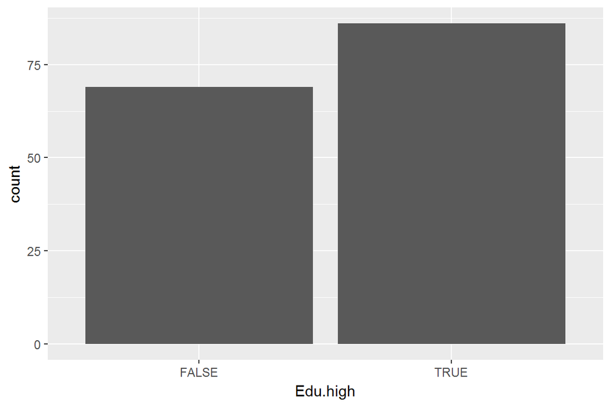

```r
ggplot(data = human, aes(x = Edu.high)) + geom_bar()
```

Next we can draw simple density plots for our continuous variables to get a clear perspective on their distributions. we can see that not really a signle one of our variables has a distribution resembling a normal distribution. Instead, some of the variables have very skewed distributions and some display high kurtosis.

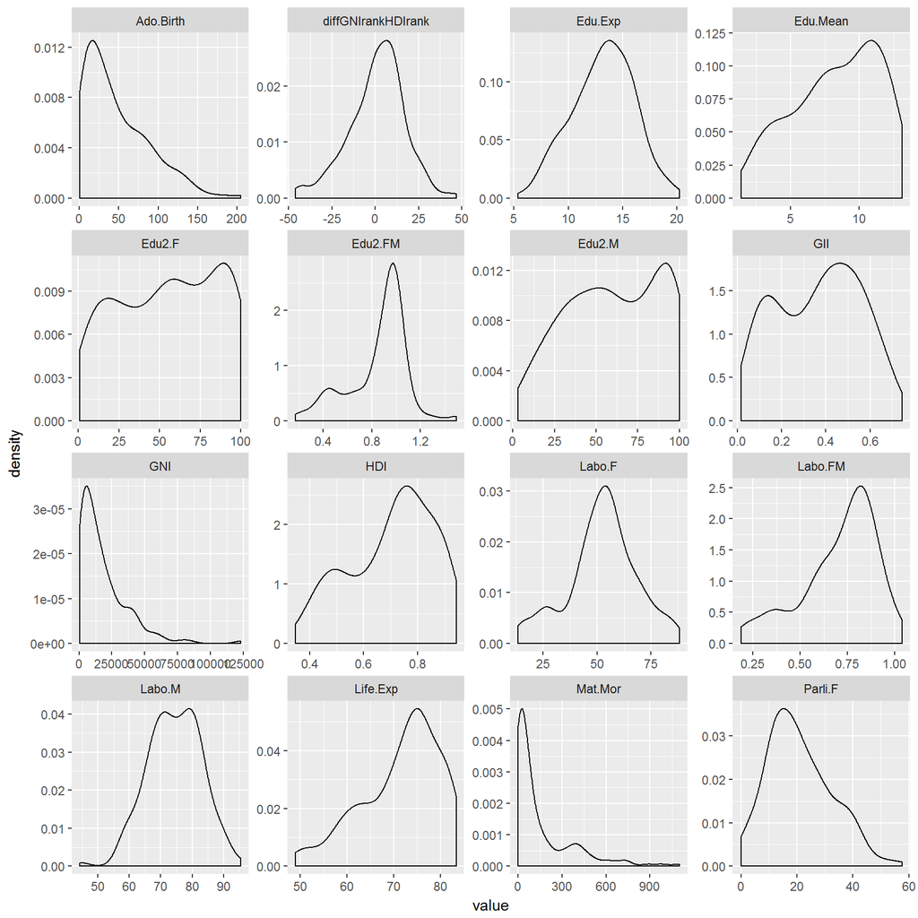

```r
# Start with choosing the columns with continuous variables:
continuous <- c("HDI","Life.Exp","Edu.Exp", "Edu.Mean", "GNI", "diffGNIrankHDIrank", "GII", "Mat.Mor", "Ado.Birth", "Parli.F", "Edu2.F", "Edu2.M", "Labo.F", "Labo.M", "Edu2.FM", "Labo.FM")

# select the 'keep_columns' to create a new dataset
human_cont <- dplyr::select(human, one_of(continuous))

# Draw the plots:
human_cont %>%
  gather() %>%
  ggplot(aes(value)) + facet_wrap(~ key, scales = "free") + geom_density()
```

*(Note that there is no point in drawing a bar plot or a density plot for variables HDIrank and GIIrank, as these are simply rankings of the different countries in our data set.)*

Let’s also print box plots of the continuous variables. Recall that in a box plot the bottom and top of the box represent the first and third quartiles, and the band inside the box represents the median. The whiskers indicate variability outside the quartiles and outliers are represented by the individual dots.

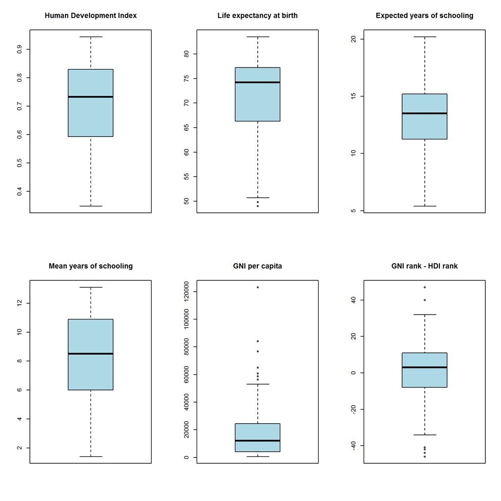

```r
par(mfrow=c(2,3))
boxplot(human$HDI,col="lightblue",main="Human Development Index")
boxplot(human$Life.Exp,col="lightblue",main="Life expectancy at birth")
boxplot(human$Edu.Exp,col="lightblue",main="Expected years of schooling")
boxplot(human$Edu.Mean,col="lightblue",main="Mean years of schooling")
boxplot(human$GNI,col="lightblue",main="GNI per capita")
boxplot(human$diffGNIrankHDIrank,col="lightblue",main="GNI rank - HDI rank")
```

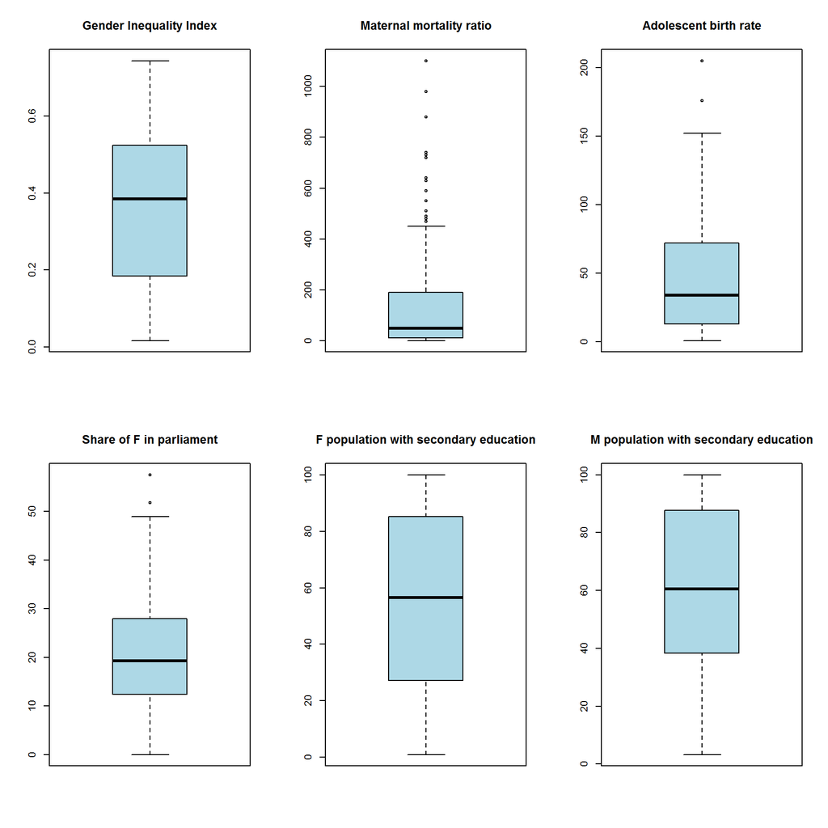

```r
boxplot(human$GII,col="lightblue",main="Gender Inequality Index")
boxplot(human$Mat.Mor,col="lightblue",main="Maternal mortality ratio")
boxplot(human$Ado.Birth,col="lightblue",main="Adolescent birth rate")
boxplot(human$Parli.F,col="lightblue",main="Share of F in parliament")
boxplot(human$Edu2.F,col="lightblue",main="F population with secondary education")
boxplot(human$Edu2.M,col="lightblue",main="M population with secondary education")
```

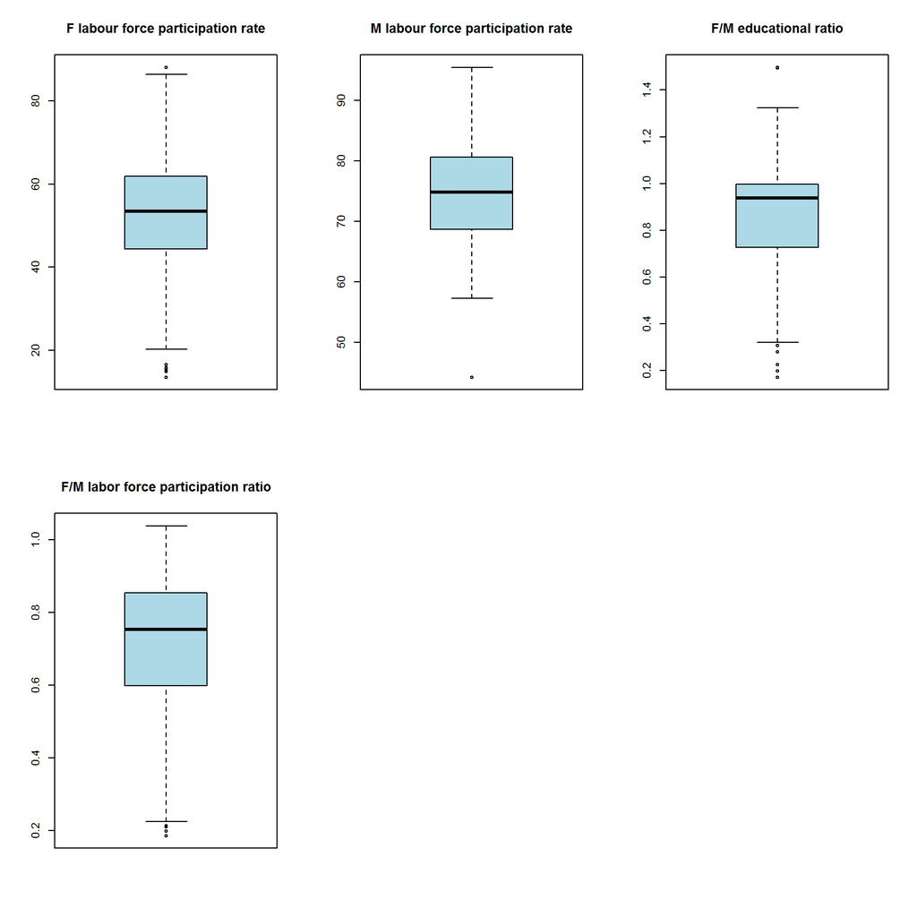

```r
boxplot(human$Labo.F,col="lightblue",main="F labour force participation rate")
boxplot(human$Labo.M,col="lightblue",main="M labour force participation rate")
boxplot(human$Edu2.FM,col="lightblue",main="F/M educational ratio")
boxplot(human$Labo.FM,col="lightblue",main="F/M labor force participation ratio")
```

## Visualizing the relationships between the variables

Next let’s move on to study the relations between the variables to find candidates for our logistic model. We will draw different visualizations of the data: scatterplots and a correlation plot. From the pairwise scatterplots we can immediately spot some clear correlations, but these are more easily grasped from the correlation plot.

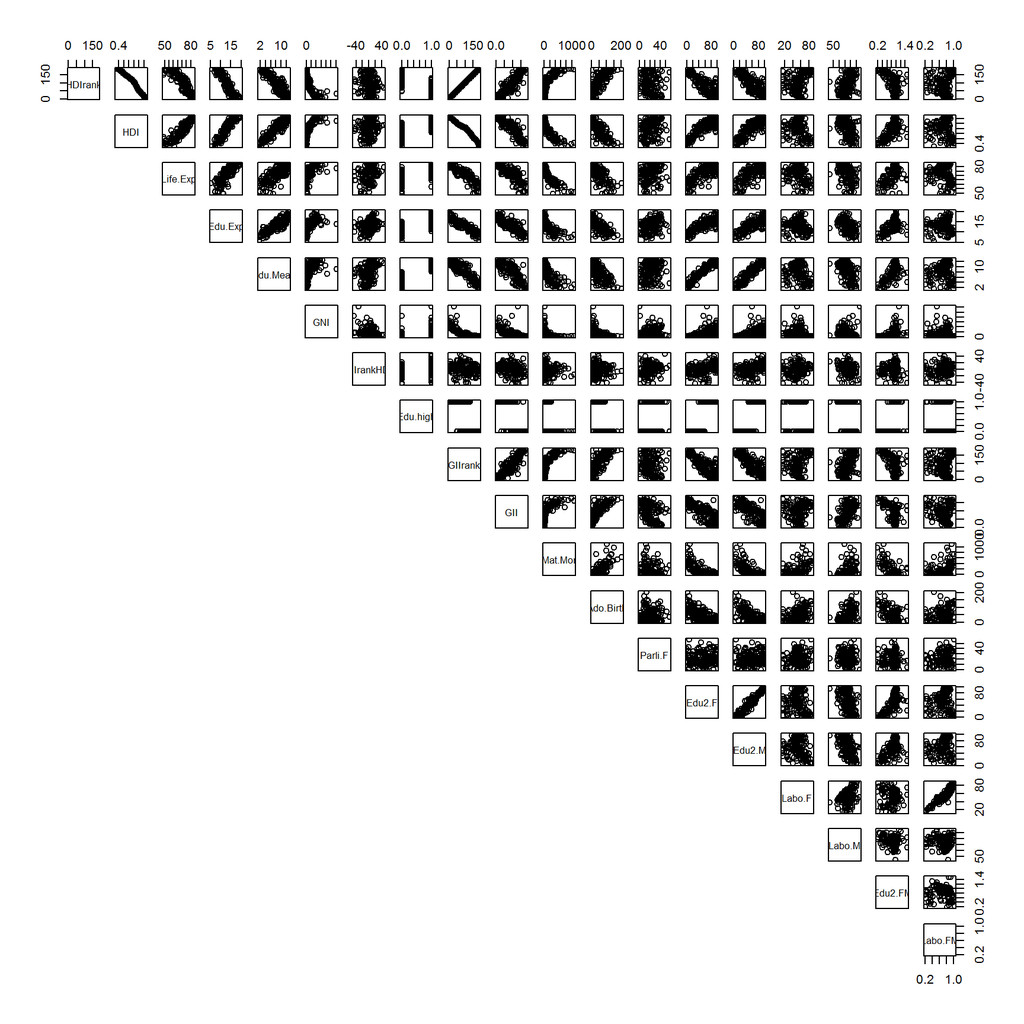

```r
#scatterplots
pairs(human,lower.panel = NULL)
```

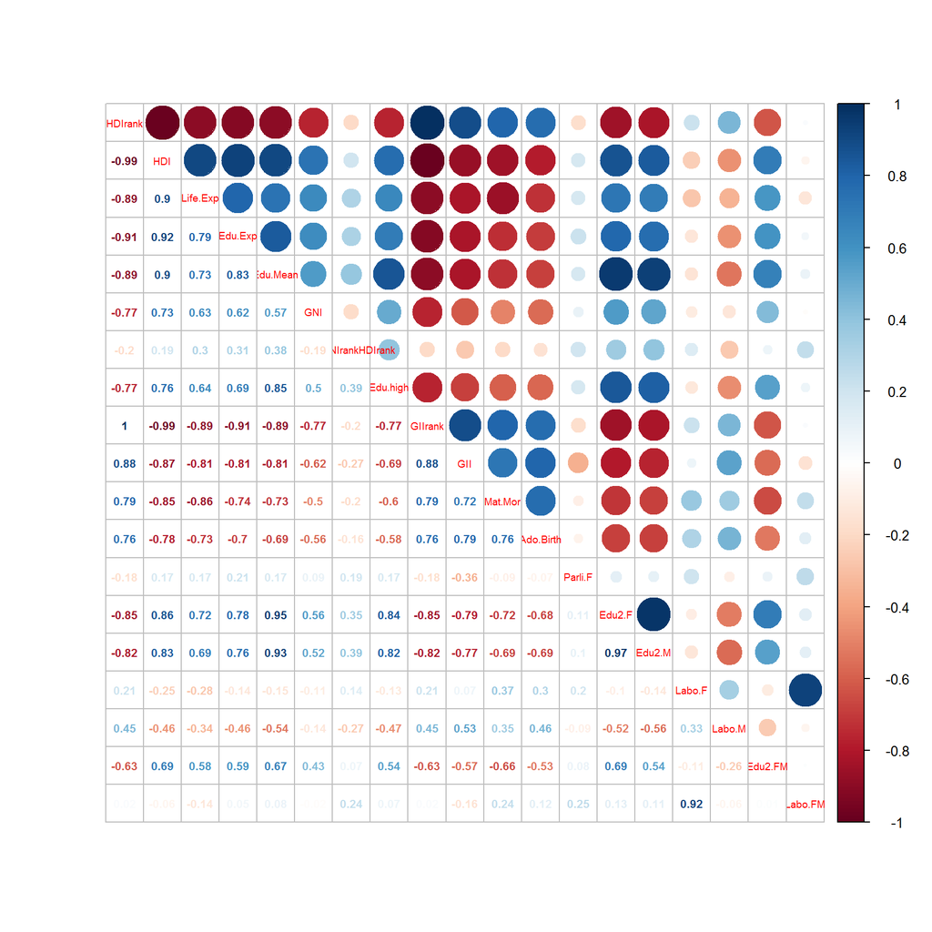

```r
#correlation plot
cor_matrix<-cor(human) %>% round(2)
corrplot.mixed(cor_matrix,number.cex=0.65,tl.cex=0.6)
```

From the correlation plot we can easily see that there are a number of variables we could drop in order to simplify our analysis, as there appears to be not much correlatin with our variable of interest, Edu.high. These variables the share of female representation in parliament (Parli.F), female labor force participation (Labo.F) and F/M labor force participation ratio. The correlation between male labor force participation and Edu.high is also quite low, so we’ll drop Labo.M also. We will also drop variables related to the HDI index (HDI, HDIrank and diffGNIrankHDIrank), because mean years of schooling is a component of these, and we wish to avoid endogeneity issues. For the same reason, let’s drop expected years of schooling and mean years of schooling (Edu.Exp and Edu.Mean).

Thus we are left with the following variables:

| Variable | Definition |
| --- | --- |
| Life.Exp | Life expectancy at birth, years |
| GNI | Gross national income (GNI) per capita, 2011 PPP $ |
| Edu.high | A dummy taking value 1, if country has higher than average mean years of schooling, value 0 otherwise |
| GIIrank | Ranking in the Gender Inequality Index |
| GII | Gender Inequality Index, value |
| Mat.Mor | Maternal mortality ratio, deaths per 100,000 live births |
| Ado.Birth | Adolescent birth rate, births per 1,000 women ages 15-19 |
| Edu2.F | Female population with at least some secondary education, % ages 25 and older |
| Edu2.M | Male population with at least some secondary education, % ages 25 and older |
| Edu2.FM | The ratio between the shares of female and male population with at least some secondary education |

Let’s the modify our data set accordingly and see if we can make out some clearer relationships between the variables:

```r
# Modify the data set:

# choose a handful of columns to keep
keep_columns <- c("Life.Exp", "GNI", "Edu.high", "GIIrank", "GII", "Mat.Mor", "Ado.Birth", "Edu2.F", "Edu2.M", "Edu2.FM")

# select the 'keep_columns' to create a new dataset
human_ <- dplyr::select(human, one_of(keep_columns))

glimpse(human_)
```

```
## Observations: 155
## Variables: 10
## $ Life.Exp  <dbl> 81.6, 82.4, 83.0, 80.2, 81.6, 80.9, 80.9, 79.1, 82.0...
## $ GNI       <int> 64992, 42261, 56431, 44025, 45435, 43919, 39568, 529...
## $ Edu.high  <lgl> TRUE, TRUE, TRUE, TRUE, TRUE, TRUE, TRUE, TRUE, TRUE...
## $ GIIrank   <int> 1, 2, 3, 4, 5, 6, 6, 8, 9, 9, 11, 14, 14, 16, 17, 18...
## $ GII       <dbl> 0.067, 0.110, 0.028, 0.048, 0.062, 0.041, 0.113, 0.2...
## $ Mat.Mor   <int> 4, 6, 6, 5, 6, 7, 9, 28, 11, 8, 6, 4, 8, 4, 27, 2, 1...
## $ Ado.Birth <dbl> 7.8, 12.1, 1.9, 5.1, 6.2, 3.8, 8.2, 31.0, 14.5, 25.3...
## $ Edu2.F    <dbl> 97.4, 94.3, 95.0, 95.5, 87.7, 96.3, 80.5, 95.1, 100....
## $ Edu2.M    <dbl> 96.7, 94.6, 96.6, 96.6, 90.5, 97.0, 78.6, 94.8, 100....
## $ Edu2.FM   <dbl> 1.0072389, 0.9968288, 0.9834369, 0.9886128, 0.969060...
```

Now we are down to 155 observations and 10 variables. Let’s visualize the relationships between variables in this version of the data set with a correlation plot:

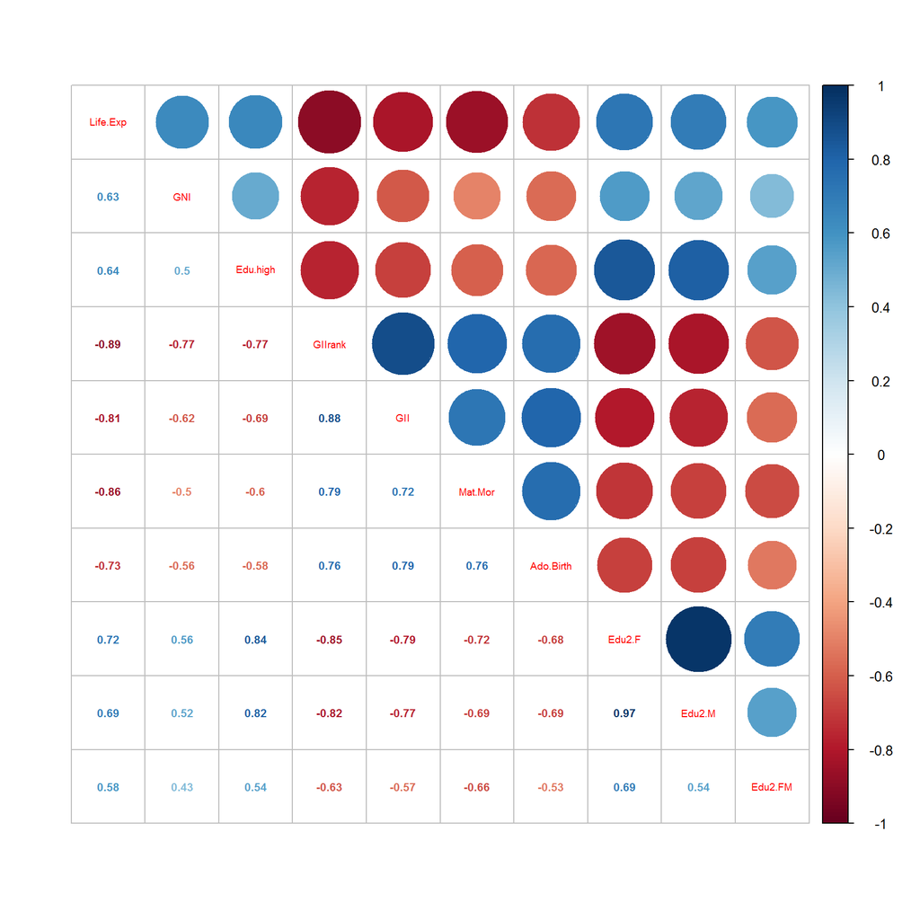

```r
#correlation plot
cor_matrix<-cor(human_) %>% round(2)
corrplot.mixed(cor_matrix,number.cex=0.65,tl.cex=0.6)
```

From the much simplified correlation plot above, we can see that the variables that display highest absolute correlation with Edu.high are share of both female and male population who recieve at least some secondary education (positive correlation), the Gender Inequality Index ranking and value of the country (negative correlation) and life expectancy (positive correlation). These are all perfectly plausible and intuitive relationships: it means that a country that manages to educate a larger share of its population, that treats its male and female citizens relatively equally and has high standards of living in terms of life expectancy will manage to keep its citizens in school for longer.

Interestingly, contrary to our initial hypothesis, gross national income displays the lowest correlation with Edu.high among these variables. Our two other initial hypothesis seem to be confirmed by the data.

## Simplifying things

For the purpose of our logistic regression, we will further drop variable GIIrank, because it essentially measures the same thing as GII.

```r
# Modify the data set further:

# choose a handful of columns to keep
keep_columns <- c("Life.Exp", "GNI", "Edu.high", "GII", "Mat.Mor", "Ado.Birth", "Edu2.F", "Edu2.M", "Edu2.FM")

# select the 'keep_columns' to create a new dataset
human_edu <- dplyr::select(human, one_of(keep_columns))

glimpse(human_edu)
```

```
## Observations: 155
## Variables: 9
## $ Life.Exp  <dbl> 81.6, 82.4, 83.0, 80.2, 81.6, 80.9, 80.9, 79.1, 82.0...
## $ GNI       <int> 64992, 42261, 56431, 44025, 45435, 43919, 39568, 529...
## $ Edu.high  <lgl> TRUE, TRUE, TRUE, TRUE, TRUE, TRUE, TRUE, TRUE, TRUE...
## $ GII       <dbl> 0.067, 0.110, 0.028, 0.048, 0.062, 0.041, 0.113, 0.2...
## $ Mat.Mor   <int> 4, 6, 6, 5, 6, 7, 9, 28, 11, 8, 6, 4, 8, 4, 27, 2, 1...
## $ Ado.Birth <dbl> 7.8, 12.1, 1.9, 5.1, 6.2, 3.8, 8.2, 31.0, 14.5, 25.3...
## $ Edu2.F    <dbl> 97.4, 94.3, 95.0, 95.5, 87.7, 96.3, 80.5, 95.1, 100....
## $ Edu2.M    <dbl> 96.7, 94.6, 96.6, 96.6, 90.5, 97.0, 78.6, 94.8, 100....
## $ Edu2.FM   <dbl> 1.0072389, 0.9968288, 0.9834369, 0.9886128, 0.969060...
```

For the sake of further visualization, let’s draw one more plot on the variables.

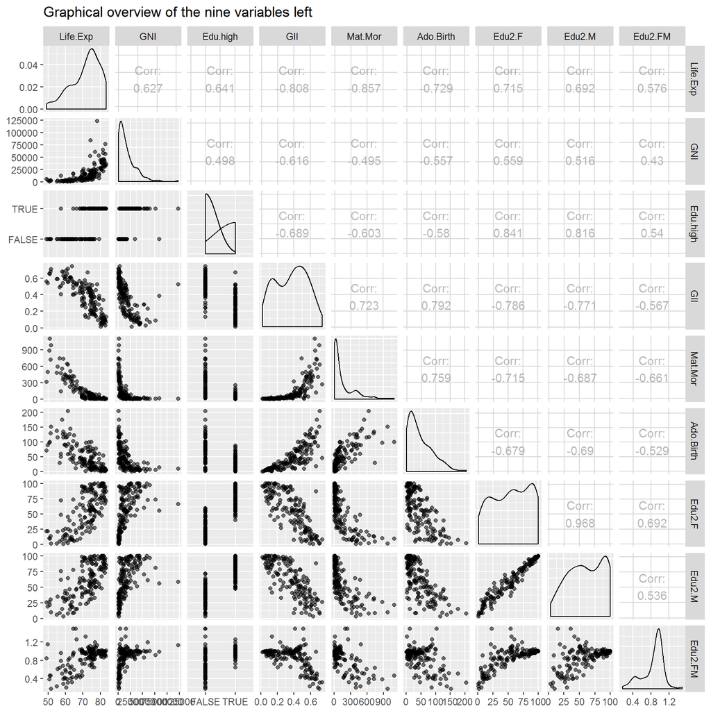

```r
ggpairs(human_edu, mapping = aes(alpha = 0.3), lower = list(combo = wrap("facethist")), title ="Graphical overview of the nine variables left")
```

## Choosing the independent variables and formulating hypothesis

Based on this analysis we will choose our independent variables to be the following:

| Variable | Definition | sign of correlation |
| --- | --- | --- |
| Life.Exp | Life expectancy at birth, years | positive |
| GII | Gender Inequality Index, value | negative |
| Mat.Mor | Maternal mortality ratio, deaths per 100,000 live births | negative |
| Ado.Birth | Adolescent birth rate, births per 1,000 women ages 15-19 | negative |
| Edu2.F | Female population with at least some secondary education, % ages 25 and older | positive |
| Edu2.M | Male population with at least some secondary education, % ages 25 and older | positive |

Let’s formulate our data driven **hypothesis** as: the mean years of schooling is likely to be higher than average in countries

- where there is gender equality, reflected by a low GII index
- where a larger share of especially the female, but also male population receives secondary education
- where social norms encourage staying in school, reflected by low rates of adolescent births
- where people tend to live longer lives, reflected by life expectancy
- where health care is adequate, reflected my low rates of maternal mortality

## A closer look on the chosen variables

Next we want to further see what the relationships between our independent variables and our dependent variable are. We will use cross-tabulations and box plots to do this.

### Cross-tabulations

From the cross-tabulation we can clearly see that the data appears to support our hypothesis. Mean of GII value, maternal mortality and adolescence birth rate are markedly higher for the countries with less than average mean years of schooling (i.e. Edu.high = FALSE). Further, the mean values of life expectancy and share of population with secondary schooling is markedly higher for the countries with higher than average mean years of schooling.

```r
human_edu %>% group_by(Edu.high) %>% summarise(count = n(), mean_Life.Exp = mean(Life.Exp), mean_GII = mean(GII), mean_Mat.Mor = mean(Mat.Mor), mean_Ado.Birth = mean(Ado.Birth), mean_Edu2.F = mean(Edu2.F), mean_Edu2.M = mean(Edu2.M))
```

```
## # A tibble: 2 x 8
##   Edu.high count mean_Life.Exp  mean_GII mean_Mat.Mor mean_Ado.Birth
##      <lgl> <int>         <dbl>     <dbl>        <dbl>          <dbl>
## 1    FALSE    69      65.71159 0.5127101     291.2754       73.67681
## 2     TRUE    86      76.42093 0.2480814      35.0000       25.88256
## # ... with 2 more variables: mean_Edu2.F <dbl>, mean_Edu2.M <dbl>
```

### Box-plots

Our hypothesis also receive confirmation from the box plots drawn below: the two boxes in each of the plots are clearly in different.

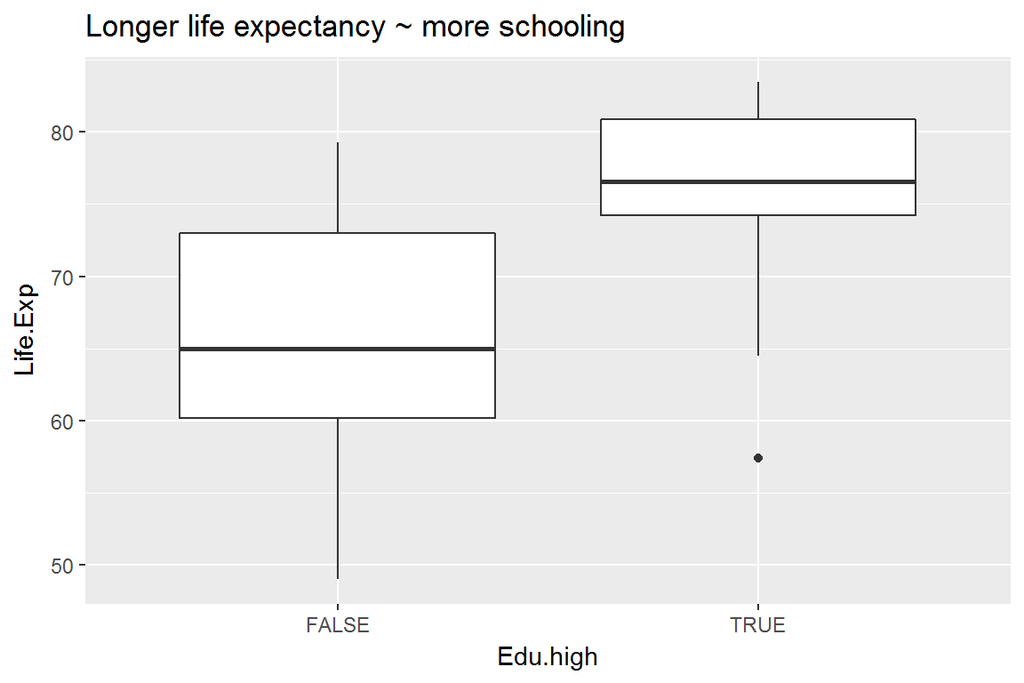

```r
ggplot(human_edu, aes(x = Edu.high, y = Life.Exp)) + geom_boxplot() + ylab("Life.Exp") + ggtitle("Longer life expectancy ~ more schooling")
```

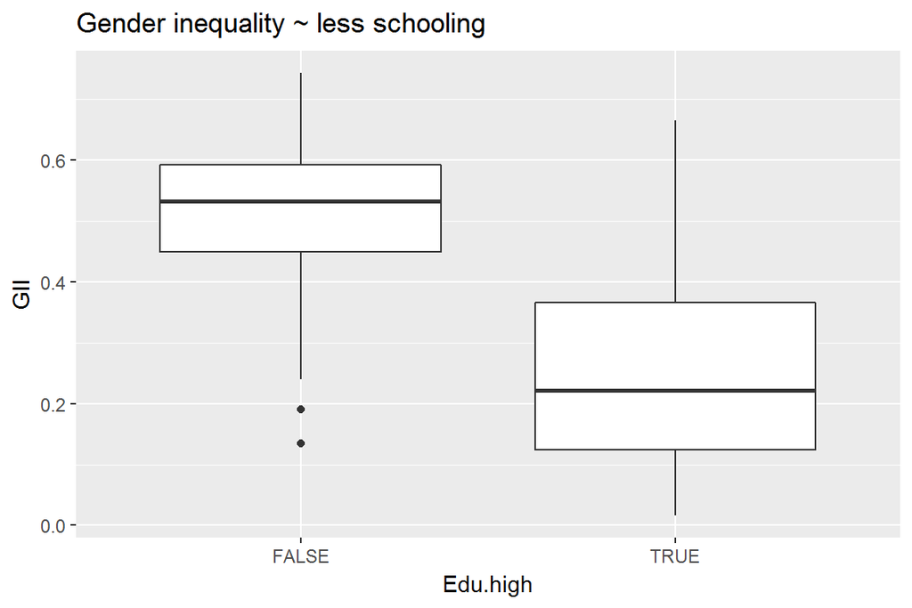

```r
ggplot(human_edu, aes(x = Edu.high, y = GII)) + geom_boxplot() + ylab("GII") + ggtitle("Gender inequality ~ less schooling")
```

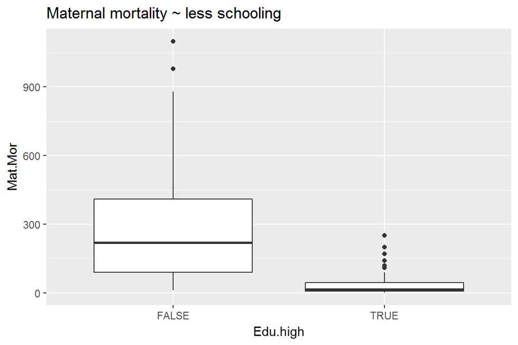

```r
ggplot(human_edu, aes(x = Edu.high, y = Mat.Mor)) + geom_boxplot() + ylab("Mat.Mor") + ggtitle("Maternal mortality ~ less schooling")
```

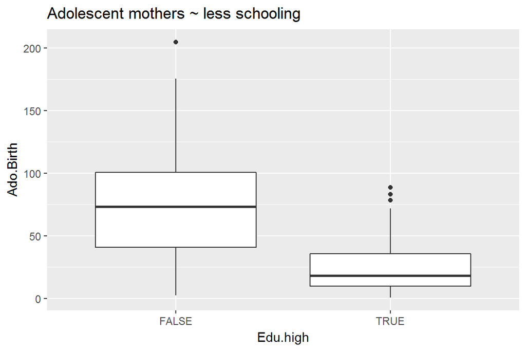

```r
ggplot(human_edu, aes(x = Edu.high, y = Ado.Birth)) + geom_boxplot() + ylab("Ado.Birth") + ggtitle("Adolescent mothers ~ less schooling")
```

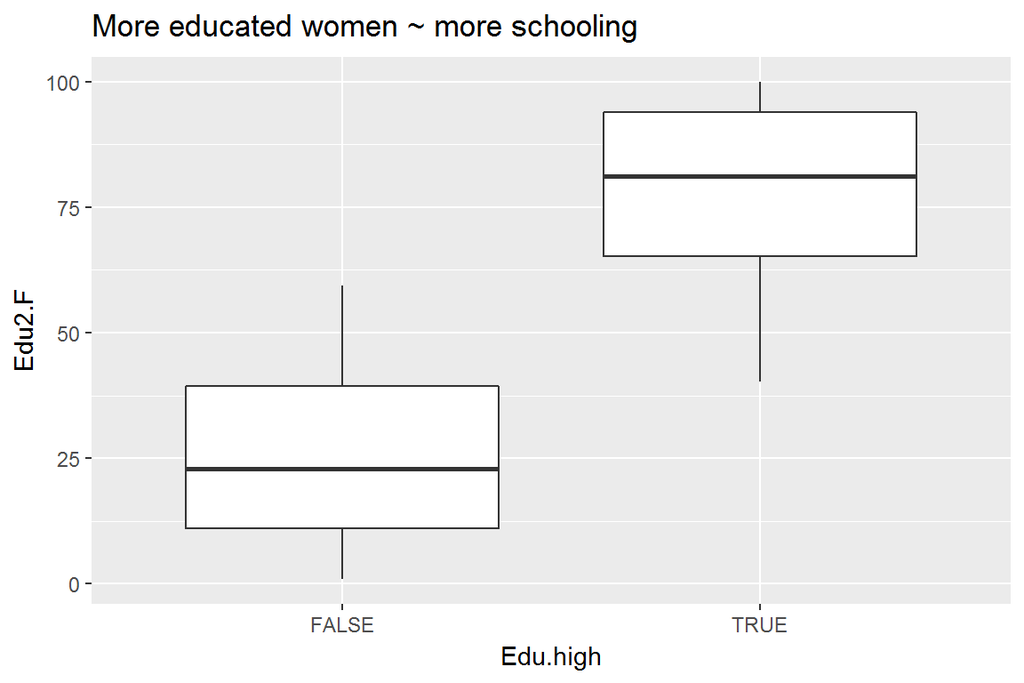

```r
ggplot(human_edu, aes(x = Edu.high, y = Edu2.F)) + geom_boxplot() + ylab("Edu2.F") + ggtitle("More educated women ~ more schooling")
```

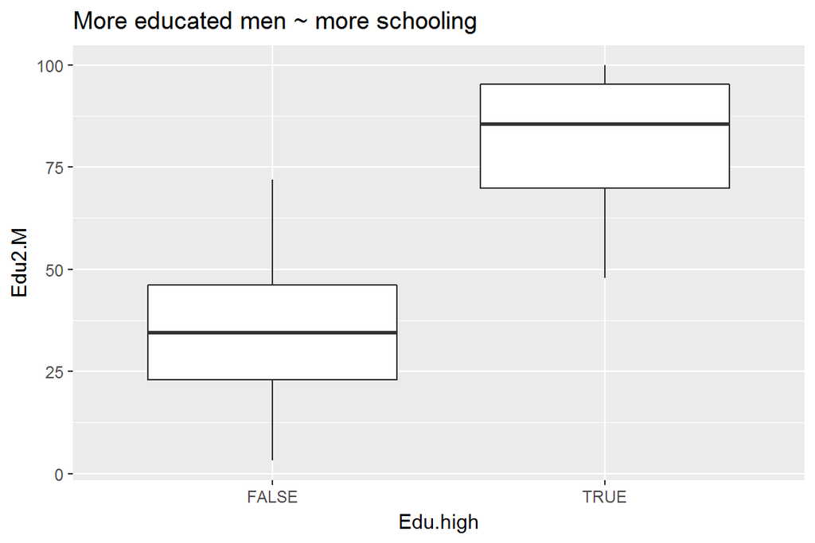

```r
ggplot(human_edu, aes(x = Edu.high, y = Edu2.M)) + geom_boxplot() + ylab("Edu2.M") + ggtitle("More educated men ~ more schooling")
```

# 6. Methods

## Logistic regression

To study the relationships between our variable of interest, Edu.high, and the independent variables, we will use logistic regression. Logistic regression should be used when the dependent variable is categorical or dichotomous (binary), i.e. can take only different values. These values can be 0 and 1, or TRUE and FALSE as they are in the present case. The logistic regression model enables us to estimate the probablity of a binary response on independent variables, which can also be called features or predictors.

The most important difference between a logistic regression model and a linear regression model is in assumptions. As the outcomes are not linear, the assumptions of linear regression do not hold and residuals cannot be normally distributed. If linear regression is fitted to a dependent variable with binary values, the results are usually nonsensical.

It is worth noting that even though the concept of a binary dependent variable doesn’t seem outlandish, the method of logistic regression was developed only in 1958.

Note that cases when the dependent variable has more than two outcome values require using multinomial logistic regression. As our dependent variable takes only values TRUE or FALSE, we can use the simple logistic regression.

## Odds ratios

With logistic regression, the summary of the results the model gives as per se do not tell that much about the quantity of the effects we are documenting. To be able to evaluate the magnitude of the effects the independent variables have on the dependent variables we have to calculate the odds and the odds ratios.

## Predictions

A logistic regression model is evaluated and validated by studying its predictive abilities. This can be done by letting the model predict the value of the dependent variable based on the independent variables, i.e. predictors, and then comparing the predictions to the actual observations. One can also calculate a training error for the model, whic gives the total proportion of inaccurately classified individuals, and perform a cross-validation on the model.

# 7. Results

In this part we will use logistic regression to gain more solid knowledge on the effect our chosen variables have on the target variable, the dichotomous Edu.high.

Let’s start with fitting the logistic regression model. For the sake of recap, our variables are:

| Dependent variable | Definition |
| --- | --- |
| Edu.high | TRUE, if mean of school years more than average, FALSE otherwise |

| Independent variables | Definition |
| --- | --- |
| Life.Exp | Life expectancy at birth, years |
| GII | Gender Inequality Index, value |
| Mat.Mor | Maternal mortality ratio, deaths per 100,000 live births |
| Ado.Birth | Adolescent birth rate, births per 1,000 women ages 15-19 |
| Edu2.F | Female population with at least some secondary education, % ages 25 and older |
| Edu2.M | Male population with at least some secondary education, % ages 25 and older |

## Fitting the model

```r
m1 <- glm(Edu.high ~ Life.Exp + GII + Mat.Mor + Ado.Birth + Edu2.F + Edu2.M , data = human_edu, family = "binomial")
summary(m1)
```

```
##
## Call:
## glm(formula = Edu.high ~ Life.Exp + GII + Mat.Mor + Ado.Birth +
##     Edu2.F + Edu2.M, family = "binomial", data = human_edu)
##
## Deviance Residuals:
##      Min        1Q    Median        3Q       Max
## -2.43571  -0.03463   0.00274   0.03110   1.64079
##
## Coefficients:
##               Estimate Std. Error z value Pr(>|z|)
## (Intercept) -23.905798  13.162339  -1.816  0.06934 .
## Life.Exp      0.172133   0.153290   1.123  0.26147
## GII          -6.785446   4.839528  -1.402  0.16089
## Mat.Mor       0.004449   0.009341   0.476  0.63384
## Ado.Birth     0.021979   0.020306   1.082  0.27908
## Edu2.F        0.160555   0.056593   2.837  0.00455 **
## Edu2.M        0.073875   0.052043   1.419  0.15576
## ---
## Signif. codes:  0 '***' 0.001 '**' 0.01 '*' 0.05 '.' 0.1 ' ' 1
##
## (Dispersion parameter for binomial family taken to be 1)
##
##     Null deviance: 213.007  on 154  degrees of freedom
## Residual deviance:  43.644  on 148  degrees of freedom
## AIC: 57.644
##
## Number of Fisher Scoring iterations: 8
```

Our second iteration of the model thus studies the effect of five independent variables on the dependent variable. The model is fitted and its summary is printed below:

```r
m2 <- glm(Edu.high ~ Life.Exp + GII + Ado.Birth + Edu2.F + Edu2.M , data = human_edu, family = "binomial")
summary(m2)
```

```
##
## Call:
## glm(formula = Edu.high ~ Life.Exp + GII + Ado.Birth + Edu2.F +
##     Edu2.M, family = "binomial", data = human_edu)
##
## Deviance Residuals:
##      Min        1Q    Median        3Q       Max
## -2.37616  -0.02747   0.00388   0.04094   1.57842
##
## Coefficients:
##              Estimate Std. Error z value Pr(>|z|)
## (Intercept) -19.18295    8.44530  -2.271  0.02312 *
## Life.Exp      0.11358    0.09340   1.216  0.22395
## GII          -6.32830    4.59493  -1.377  0.16844
## Ado.Birth     0.02544    0.01906   1.334  0.18212
## Edu2.F        0.15267    0.05218   2.926  0.00343 **
## Edu2.M        0.07460    0.05153   1.448  0.14768
## ---
## Signif. codes:  0 '***' 0.001 '**' 0.01 '*' 0.05 '.' 0.1 ' ' 1
##
## (Dispersion parameter for binomial family taken to be 1)
##
##     Null deviance: 213.007  on 154  degrees of freedom
## Residual deviance:  43.863  on 149  degrees of freedom
## AIC: 55.863
##
## Number of Fisher Scoring iterations: 8
```

It may seem that nothing much has changed, as the only independent variable to have a statistically significant effect is still Edu2.F. But look closer, and you’ll notice that the z values of variables except GII have edged upwards. Let’s thus continue in the same manner and drop the variable that now has the lowest z value, i.e. life expectancy.

```r
m3 <- glm(Edu.high ~ GII + Ado.Birth + Edu2.F + Edu2.M , data = human_edu, family = "binomial")
summary(m3)
```

```
##
## Call:
## glm(formula = Edu.high ~ GII + Ado.Birth + Edu2.F + Edu2.M, family = "binomial",
##     data = human_edu)
##
## Deviance Residuals:
##      Min        1Q    Median        3Q       Max
## -2.43710  -0.03396   0.00396   0.04325   1.55457
##
## Coefficients:
##              Estimate Std. Error z value Pr(>|z|)
## (Intercept) -10.00843    3.30544  -3.028  0.00246 **
## GII          -7.96456    4.24516  -1.876  0.06063 .
## Ado.Birth     0.02131    0.01793   1.189  0.23457
## Edu2.F        0.15992    0.05081   3.147  0.00165 **
## Edu2.M        0.06782    0.04994   1.358  0.17444
## ---
## Signif. codes:  0 '***' 0.001 '**' 0.01 '*' 0.05 '.' 0.1 ' ' 1
##
## (Dispersion parameter for binomial family taken to be 1)
##
##     Null deviance: 213.007  on 154  degrees of freedom
## Residual deviance:  45.445  on 150  degrees of freedom
## AIC: 55.445
##
## Number of Fisher Scoring iterations: 8
```

**Interestingly, it thus seems that education is not so much a matter of standards of living or health, as it is about gender equality.**

Based on these results, let’s fit one more model, with only GII and Edu2.F as the independent variables. This will be our final model, for which we will calculate the odds ratios and their confidence intervals. This way we can quantify the effect between our explanatory variables and target variable. We will also use this version of the model to test its predictive power.

```r
m4 <- glm(Edu.high ~ GII + Edu2.F , data = human_edu, family = "binomial")
summary(m4)
```

```
##
## Call:
## glm(formula = Edu.high ~ GII + Edu2.F, family = "binomial", data = human_edu)
##
## Deviance Residuals:
##      Min        1Q    Median        3Q       Max
## -2.17170  -0.05641   0.00981   0.07509   1.67073
##
## Coefficients:
##             Estimate Std. Error z value Pr(>|z|)
## (Intercept) -7.49018    2.46199  -3.042  0.00235 **
## GII         -5.27936    3.13840  -1.682  0.09253 .
## Edu2.F       0.18326    0.04239   4.323 1.54e-05 ***
## ---
## Signif. codes:  0 '***' 0.001 '**' 0.01 '*' 0.05 '.' 0.1 ' ' 1
##
## (Dispersion parameter for binomial family taken to be 1)
##
##     Null deviance: 213.007  on 154  degrees of freedom
## Residual deviance:  47.836  on 152  degrees of freedom
## AIC: 53.836
##
## Number of Fisher Scoring iterations: 8
```

Now the effect of Edu2.F is highly significant, whereas the effect of GII remains modestly significant.

## Odds ratios and confidence intervals

Next we will present and interpret the coefficients of the model as odds ratios and calculate their confidence intervals.

As we are working with a logistic regression, we can interpret the odds ratios for non-binary variables as odds ratios between a unit change vs. no change in the corresponding explanatory variable. Thus the odds ratio of “Edu2.F”, 1.2, can be interpreted as the ratio between the odds of a country schooling 1 % more of it’s female population having a higher than average mean years of schooling and the odds of a country that doesn’t increase schooling of girls having a higher than average mean years of schooling. That is

> $OR = \frac{Pr(Edu.high = 1 | \Delta Edu2.F = 1 \% )}{Pr(Edu.high = 1 | \Delta Edu2.F = 0 \% )}$

and for our other independent variable GII:

> $OR = \frac{Pr(Edu.high = 1 | \Delta GII = 1 )}{Pr(Edu.high = 1 | \Delta GII = 0 )}$

Now let’s calculate the odds ratios and their confidence intervals. Note that the odds ratio for positive effect should be larger than one and for negative effect less than one.

```r
# print out the odds ratios (OR) with their confidence intervals (CI)
cbind(OR, CI)
```

```
##                       OR        2.5 %     97.5 %
## (Intercept) 0.0005585442 2.047187e-06 0.03990301
## GII         0.0050956990 5.902499e-06 1.76002604
## Edu2.F      1.2011254765 1.122173e+00 1.33001506
```

Note however that the confidence interval of GII includes 1, which means that its effect may infact be statistically indifferent from zero. This is not that surprising, if one recalls that in the logistic regression the effect of GII was only significant at the lowest possible confidence level.

## Predictions

Now we will evaluate our model by studying its predictive abilities.

We can use the predict() function to make predictions from this model. We start by adding two columns to our data set: “probability” with the predicted probabilities and “prediction” which takes value TRUE if the value of “probability” is larger than 0.5.

```r
# predict() the probability of high_use
probabilities <- predict(m4, type = "response")

# add the predicted probabilities to 'alc'
human_edu <- mutate(human_edu, probability = probabilities)

# use the probabilities to make a prediction of high_use
human_edu <- mutate(human_edu, prediction = probability>0.5)
```

Next, let’s take a look at the first ten and the last ten rows of our data set. We can see that the predictions are correct in all these cases.

```r
# see the first and the last ten original classes, predicted probabilities, and class predictions
dplyr::select(human_edu, Edu.high, Edu2.F, GII, probability, prediction) %>% head(10)
```

```
##    Edu.high Edu2.F   GII probability prediction
## 1      TRUE   97.4 0.067   0.9999549       TRUE
## 2      TRUE   94.3 0.110   0.9999000       TRUE
## 3      TRUE   95.0 0.028   0.9999430       TRUE
## 4      TRUE   95.5 0.048   0.9999422       TRUE
## 5      TRUE   87.7 0.062   0.9997399       TRUE
## 6      TRUE   96.3 0.041   0.9999519       TRUE
## 7      TRUE   80.5 0.113   0.9987276       TRUE
## 8      TRUE   95.1 0.280   0.9997882       TRUE
## 9      TRUE  100.0 0.129   0.9999611       TRUE
## 10     TRUE   95.0 0.157   0.9998873       TRUE
```

```r
dplyr::select(human_edu, Edu.high, Edu2.F, GII, probability, prediction) %>% tail(10)
```

```
##     Edu.high Edu2.F   GII  probability prediction
## 146    FALSE   12.8 0.673 1.669800e-04      FALSE
## 147    FALSE   15.4 0.651 3.019792e-04      FALSE
## 148    FALSE    7.7 0.677 6.421510e-05      FALSE
## 149    FALSE    1.4 0.591 3.187314e-05      FALSE
## 150    FALSE   10.0 0.650 1.128690e-04      FALSE
## 151    FALSE    0.9 0.631 2.354629e-05      FALSE
## 152    FALSE    5.3 0.492 1.098430e-04      FALSE
## 153    FALSE    1.7 0.706 1.834999e-05      FALSE
## 154    FALSE   10.1 0.655 1.119618e-04      FALSE
## 155    FALSE    2.4 0.713 2.010468e-05      FALSE
```

However, that doesn’t mean that our model is perfect in predicting the outcome. We can take a better look at the actual predictive performance of our model by the help of the following cross tabulations:

```r
# tabulate the target variable versus the predictions
table(Edu.high = human_edu$Edu.high, prediction = human_edu$prediction)
```

```
##         prediction
## Edu.high FALSE TRUE
##    FALSE    61    8
##    TRUE      5   81
```

```r
# tabulate the target variable versus the predictions with margings:
table(Edu.high = human_edu$Edu.high, prediction = human_edu$prediction) %>% prop.table() %>% addmargins()
```

```
##         prediction
## Edu.high      FALSE       TRUE        Sum
##    FALSE 0.39354839 0.05161290 0.44516129
##    TRUE  0.03225806 0.52258065 0.55483871
##    Sum   0.42580645 0.57419355 1.00000000
```

From the first 2x2 cross tabulation of predictions versus the actual values we can see that our model is not indeed perfect, but it is surprisingly good. In 8 cases our model predicted a country to have more than average mean years of schooling, when in fact the country had less, and vice versa in 5 cases. On the other hand, in 142 cases the prediction is correct.

From the second table we can see the share of correct and incorrect predictions. In 5.1 % of cases our model predicted TRUE when FALSE was correct and vice versa in 3.2 % of cases. That is, in only 8.3 % of the cases the prediction was incorrect, which seems quite a good fit.

We can also see this in a graph that plots the true values against the predictions. Most observations for countries with more than average years of schooling, i.e. Edu.high = TRUE, are blue, i.e. predicted TRUE. The case for less than average years of schooling, i.e. Edu.high = FALSE is the oppposite, that is, most of the dots are red.

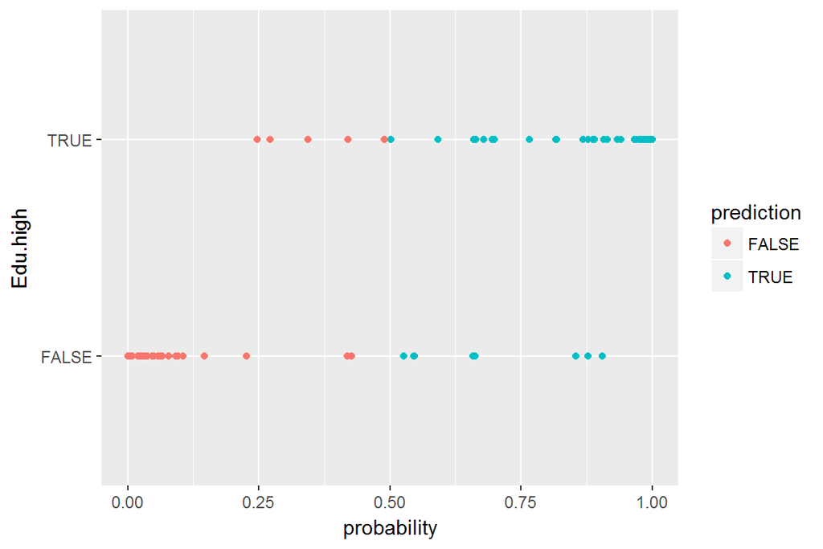

```r
# initialize a plot of 'high_use' versus 'probability' in 'alc'
g <- ggplot(human_edu, aes(x = probability, y = Edu.high, col = prediction))

# define the geom as points and draw the plot
g + geom_point()
```

## Training error

Further, we can to compute the total proportion of inaccurately classified individuals, or the the training error. For this purpose we will define a loss function and then calculate the average number of wrong predictions in the training data. The last result gives the training error, which is 8.3 %. Note that this is equal to the sum of the shares of incorrectly predicted observations, calculated above.

```r
# define a loss function (mean prediction error)
loss_func <- function(class, prob) {
  n_wrong <- abs(class - prob) > 0.5
  mean(n_wrong)
}

# call loss_func to compute the average number of wrong predictions in the (training) data
loss_func(class = human_edu$Edu.high, prob = 0)
```

```
## [1] 0.5548387
```

```r
loss_func(class = human_edu$Edu.high, prob = 1)
```

```
## [1] 0.4451613
```

```r
loss_func(class = human_edu$Edu.high, human_edu$probability)
```

```
## [1] 0.08387097
```

## Cross-validation

The last thing we presently do to test our models validity, is a cross-validation. Cross-validation is a method of testing a predictive model on unseen data. In cross-validation, the value of a loss function is computed on data not used for finding the model. Cross-validation gives a good sense of the actual predictive power of the model.

We will perform a 10-fold cross-validation for our model:

```r
# 10-fold cross-validation
cv <- cv.glm(data = human_edu, cost = loss_func, glmfit = m4, K = 10)

# average number of wrong predictions in the cross validation
cv$delta[1]
```

```
## [1] 0.09032258
```

To see what the average share of wrong predictions would have been for the other specifications of our model, we can easily calculate them also:

- for model 1 with six independent variables (Edu.high ~ Life.Exp + GII + Mat.Mor + Ado.Birth + Edu2.F + Edu2.M)

```r
# 10-fold cross-validation
cv1 <- cv.glm(data = human_edu, cost = loss_func, glmfit = m1, K = 10)

# average number of wrong predictions in the cross validation
cv1$delta[1]
```

```
## [1] 0.09677419
```

- for model 2 with five independent variables (Edu.high ~ Life.Exp + GII + Ado.Birth + Edu2.F + Edu2.M)

```r
# 10-fold cross-validation
cv2 <- cv.glm(data = human_edu, cost = loss_func, glmfit = m2, K = 10)

# average number of wrong predictions in the cross validation
cv2$delta[1]
```

```
## [1] 0.08387097
```

- for model 3 with four independent variables (Edu.high ~ GII + Ado.Birth + Edu2.F + Edu2.M)

```r
# 10-fold cross-validation
cv3 <- cv.glm(data = human_edu, cost = loss_func, glmfit = m3, K = 10)

# average number of wrong predictions in the cross validation
cv3$delta[1]
```

```
## [1] 0.09032258
```

We can see that the share of wrong predictions does not change much across the specifications.

# 8. Conclusions and discussion

We have used a logistic regression model to study whether the different variables that form the Human Development Index and the Gender Inequality Index can be used to determine if a given country has achieved a higher than average mean years of schooling. We found that of these variables, the share of female population receiving secondary education is the most important predictor of higher than average education in a given country. We found that the more a country educates its girls, the higher is the probability of it offering longer than average schooling in general. Also the GII index value plays a role: the smaller the value, i.e. the more equal the country is, the longer its population stays in school.

The results are quite interesing, because they suggest that longer schooling is first of all a matter of gender equality. That is, in those countries where girls a likely to receive the same opportunities in terms of education and in other parts of the society, also boys will benefit, because everyone will receive on average more education.

There are naturally caveats to keep in mind. First of all, our model was very simple and the variables were limited to these two indeces and their components. One should also keep in mind that correlation does not imply causality. That is, we cannot really say that educating girls results in longer schooling for all, as it might just as well be that girls receive more schooling in these countries precisely because they offer longer than average schooling.

However, our chosen method and model performed surprisingly well when evaluated in terms of their predictive power. Our model was able to predict the correct value for the target value in all but 8 % of observations. This is a very good fit.